# Book Bans in American Libraries: Impact of Politics on Inclusive Content Consumption

Converted from PDF `Ananthakrishnan-AmericanLibraryBookBans-2025-MKSC.pdf` · 22 pages · anchors: page `#pN`, block `#pN-bK`

Page 1

[figure not shown]

NOTE: figure/graphic rendered as an image from the PDF; its content is not machine-readable text. Caption (if any) follows as the next block.

**text found inside the figure**

Marketing Science

Publication details, including instructions for authors and subscription information: http://pubsonline.informs.org

Book Bans in American Libraries: Impact of Politics on Inclusive Content Consumption

Uttara M. Ananthakrishnan, Naveen Basavaraj, Sabari Rajan Karmegam, Ananya Sen, Michael D. Smith

To cite this article: Uttara M. Ananthakrishnan, Naveen Basavaraj, Sabari Rajan Karmegam, Ananya Sen, Michael D. Smith (2025) Book Bans in American Libraries: Impact of Politics on Inclusive Content Consumption. Marketing Science 44(4):933-953. https://doi.org/10.1287/mksc.2024.0716

This work is licensed under a Creative Commons Attribution 4.0 International License. You are free to copy, distribute, transmit and adapt this work, but you must attribute this work as “*Marketing Science*. Copyright © 2025 The Author(s). https://doi.org/10.1287/mksc.2024.0716, used under a Creative Commons Attribution License: https://creativecommons.org/licenses/by/4.0/.”

Copyright © 2025 The Author(s)

Please scroll down for article—it is on subsequent pages

Page 2

### **Book Bans in American Libraries: Impact of Politics on Inclusive Content Consumption**

#### **Uttara M. Ananthakrishnan,<sup>a</sup>Naveen Basavaraj,<sup>a,</sup>* Sabari Rajan Karmegam,<sup>b</sup>Ananya Sen,<sup>a</sup>Michael D. Smith<sup>a</sup>**

[figure not shown]

NOTE: complex table shown as an image of the PDF; the text below is a rough machine extraction and may be mis-aligned.

**extracted text (unreliable layout)**

#### **Keywords: book bans** <sup>•</sup> **social media** <sup>•</sup> **politics**

**1. Introduction** Book bans or challenges in public schools and libraries in the United States have been recurring events over the past several decades (Foerstel 2002). However, since 2021, there has been a significant push from state offi cials, elected representatives, individual parents, com munity members, and advocacy groups to remove books construed to deal with sensitive topics related to race and gender from public and school libraries. Although such challenges are not new, the number of book bans in a short period has made these events a subject of national debate due to their politically polarizing nature. For exam ple, the American Library Association (ALA) released a statement indicating an “alarming” increase in book ban

campaigns around the United States.<sup>1</sup> PEN America finds that books have been banned at an “unprecedented” rate just between 2021 and 2022 in 138 school districts. Critics of book bans argue that they attempt to censor informa tion and ideas and violate the First Amendment rights of students and library patrons. However, proponents of these bans refer to the broad discretion afforded to school boards by the Supreme Court and the rights of parents to voice concerns about the suitability of themes dealing with race and gender identity for children under a cer tain age.

The potential impact of such polarizing events could create a strategic dilemma for various stakeholders, including authors, publishers, and politicians. However,

933

**MARKETING SCIENCE Vol. 44, No. 4, July–August 2025, pp. 933–953 ISSN 0732-2399 (print), ISSN 1526-548X (online) https://pubsonline.informs.org/journal/mksc**

Page 3

little is known about the impact of contentious rules and legislation designed to restrict access to goods at the local level on the consumption of these goods on a larger scale. We study this phenomenon in the context of book bans instituted by local school districts and city public libraries. Our focus will be on book titles that are rela tively high-profile due to them being banned repeat edly. Although the decision to ban books is made at a ‘microgeographic’ local level, these events receive exten sive attention on social media and media coverage at the state and national level outside of those particular areas. A priori, the impact of book bans on the consumption of such content associated with diversity and inclusion topics is ambiguous. On the one hand, books banned in select locations garner statewide and national attention, which can increase the readership of these books (a phe nomenon popularly known as the “Streisand effect” Jansen and Martin 2015). On the other hand, the sensi tive nature of these book bans might result in a chilling effect, deterring consumption as parents and teachers opt to avoid controversy in a highly polarized environ ment. The impact of “hyper-local” decisions on con sumption in the aggregate can significantly impact the content strategy of authors and publishers, as well as the rhetoric used by politicians.

In this paper, using novel large-scale data on U.S. library circulation, we investigate the impact of book bans on the circulation of the top-25 most banned book titles (each banned more than five times), as defined by PEN America and the ALA, at school libraries and pub lic libraries, which is our key measure of book demand. To identify the causal effect of book bans, we use the large variation in the timing of book bans across differ ent states in a difference-in-differences event study design. Furthermore, given the widespread nature of such ban events, we study the spillovers of these bans across several dimensions. We use a variety of identifi cation strategies, such as defining one single ban event across all books, 25 ban events (one for each title), and analyzing 127 titles × state events to analyze the impact of ban events on library circulations. These top-25 titles appear in over 85% of ban events in our sample and are most likely to be “solo-banned,” leading to increased salience on news and social media. We also use data from Amazon Sales Rank to validate our key baseline result.

Across a series of specifications, using different sources of identifying variation, we find that book ban events increase the circulation of banned books by 12% compared with a set of control books. We also find spil lovers of the impact of bans with an increase in reader ship in nonfocal states. More specifically, even in states without bans, the circulation of banned books increased by 11.2% compared with control books. Interestingly, social media plays a significant role in amplifying this impact. Books that attract high visibility on Twitter

enjoy significantly higher circulation after the event than books that do not. Our effects are driven entirely by books written by less famous authors, suggesting that these events shine a light on the works of lesser- known writers. Moreover, we find that this increase in consumption is prevalent in both Blue and Red states and spills over to states that do not see any bans.<sup>2</sup> That noted, we find that the focal state that experiences the book bans sees a larger increase in circulation relative to other states. To dig deeper into the mechanism, we use patron-level data that include the age of the individual from the Seattle Public Library to show that after book bans are initiated in other states, there is an increase in readership of those books by children under the age of 18.<sup>3</sup> We validate our baseline results using Amazon sales rank data. We find a statistically and economically significant decline in sales rank, implying an increase in Amazon sales after the ban events.

In general, this increase in content consumption is related to inclusion themes, as the topics of these books often deal with issues of race, gender, and LGBTQIA. The critical question here, however, is why politicians bring such issues to the forefront, (potentially) inadver tently increasing the consumption of these books. To fur ther analyze this issue, we explore the potential to incorporate these issues as part of political rhetoric. Using emails from a set of 245 political accounts (candidates, political action committees (PACs), etc.), we analyze campaign emails to small-dollar donors and identify a marked rise in mentions of book bans, especially in com munications from Republican politicians. We provide correlational evidence to suggest that transforming book bans into a political issue or debate—what we specifically define here as “politicization”—tends to increase the amount of donations received by Republican House can didates relative to Democratic House candidates, but only in conservative states.

Our findings have strategic and managerial implica tions for a variety of stakeholders. A priori, high-profile book bans could discourage authors and publishers of books associated with diverse and inclusive content from creating such content due to potential chilling and reputational effects. This can have large downstream implications, such as the reduction in the supply of rep resentative and diverse content available to the general public. However, our results suggest that there may be a broad audience for content beyond the local public library or school district level, where contentious rules target such books. Therefore, in the aggregate, such con tentious rules could unexpectedly lead to an increase in the consumption of such content, at least in the short run. Strategically for an author, it is important to gener ate chatter on social media and news coverage in the aftermath of book bans to increase readership. More over, in terms of political strategy, politicians need to realize that although such rhetoric can potentially lead

**Ananthakrishnan et al.:** *Book Bans in American Libraries* 934 Marketing Science, 2025, vol. 44, no. 4, pp. 933–953, © 2025 The Author(s)

Page 4

to more donations, it might also inadvertently amplify the content they seek to suppress. This unexpected out come highlights the power of social media and public discourse in shaping book consumption patterns. In light of these findings, it becomes crucial that stakeholders consider the broader implications of their actions and strategies.

We contribute to several strands of Marketing and Economics literature. First, we contribute to the broad literature around “political consumerism,” which is the act of consumers trying to influence business practices using their purchasing power or “voting with their wallets” (Stolle et al. 2005, Stolle and Micheletti 2013). Schoenmueller et al. (2023) show how brand prefer ences can predict political preferences and how increas ingly polarized brand preferences are correlated with the trend in political polarization. Studies that aim to identify the causal impact of political polarization driv ing consumption are relatively new. In this emerging stream, Liaukonyt˙e et al. (2023) study the effect of the CEO of a brand (Goya) taking a political stance by praising President Donald Trump to find a (temporary) increase in sales by 22%. Wang and Lu (2022) show that when it was accidentally disclosed that a company donated to a Republican politician, sales of that good increased in Republican counties. Bursztyn et al. (2022) demonstrate how politically polarized debates around the Affordable Care Act (“Obamacare”) lead to lower participation in more Republican counties.<sup>4</sup> Mumma (2024) and Goncalves et al. (2024) take a descriptive approach in providing the landscape of book bans and the role of politics in determining the availability of children’s books in school libraries. We believe that these papers provide the foundation for our study to take the next step in analyzing causal effects. We com plement this literature by providing causal evidence on how consumption of books increases in the aggregate in the aftermath of (high-profile) book bans, in the pro cess shedding light on a context where formal restric tions exist on access to certain products at the local level or legislations are proposed around sensitive social issues. Such conditions, in turn, create a polar ized environment that could impact the consumption of the good on a broader scale. In addition, we high light a feedback loop that identifies the impact of polar izing political rhetoric through such issues in campaign emails.

Next, we contribute to the marketing literature that studies how the decision to censor a particular product leads to more scrutiny and explosion of publicity for this product. This effect, popularly dubbed the “Streisand Effect,” has been exacerbated in the age of social media (Jansen and Martin 2015, Mach 2022). Studies in this literature have examined the impact of publicity, both positive and negative, as a form of advertising. For example, Berger et al. (2010) study online reviews for

books and conclude that any publicity is good for rela tively lesser-known products, as reviews, including neg ative ones, increase product awareness and lead to increased readership. Similarly, Ahluwalia et al. (2000) and Ackerberg (2001) study the different mechanisms behind the potential role of negative publicity in inform ing consumers’ purchase decisions. More recently, Shi pilov et al. (2019) found that both positive and negative media coverage influences the adoption of governance practices by firms. In our paper, we find evidence to sug gest that banning books provides informational value about these books on the state and national stage. In par ticular, we find that book bans lead to greater coverage of these books on social media. This informational effect leads to increased consumption not only in the focal states where some public or school libraries banned these books, but also in states where these books were not banned. Our results shed light on the fact that censorship in a politically polarized environment provides informa tional value on the books being banned, leading to higher consumption of the restricted product. These results come with an important caveat. Our results do not speak to how consumption would be impacted if such bans took place at a more aggregate level—for example, if there was a federal ban on any particular book.

Finally, our paper relates to the studies examining the effectiveness of political marketing and campaigns. For example, Gordon and Hartmann (2013, 2016) study the different factors that influence the level of advertis ing in political campaigns. Studies have also analyzed how political parties leverage the media and creative elements to communicate with the electorate (Sober man and Sadoulet 2007). More recently, Petrova et al. (2021) study how social media aids new politicians to communicate with their constituency effectively and helps mitigate the incumbency gap with their competi tors. Further, Fujiwara et al. (2021) quantify the role of Twitter in the 2016 U.S. Presidential Elections, highlight ing that Twitter lowered Republican vote share. How ever, the impact of using contentious policies, rules, or legislation as a potential tool to raise funds, with social media playing a moderating role, is relatively understu died. We find that the conservative stance, which prompts such book bans, seems to lose out on the focal dimension of readership of those books more generally, at least in the short run. On the other hand, we provide suggestive evidence that (some) Republican politicians gain donations, which may provide them with an elec toral advantage.

**2. Background and Data 2.1. Background: Libraries and Book Bans in the United States** Public and school libraries play an important role in the dissemination of information for a large majority of

**Ananthakrishnan et al.:** *Book Bans in American Libraries* Marketing Science, 2025, vol. 44, no. 4, pp. 933–953, © 2025 The Author(s) 935

Page 5

adults and children in the United States. Recent research documents the positive effects of public libraries on edu cational outcomes (Gilpin et al. 2021, Karger 2021). Pub lic libraries in the United States originated in the 19th century, financed by Andrew Carnegie (Berkes and Nencka 2021). In 2019, the United States had 16,548 pub lic libraries and accounted for a large majority of book consumption in the country (Reimers and Waldfogel 2022). More than half of public schools in the United States have a full-time librarian, and often, schoolchil dren have to go to the school library once a week as part of their regular schedule (Gavigan et al. 2010). These institutional details highlight the key role of public and school libraries in allowing adults and children to access books.<sup>5</sup>

The concept of banning books in classrooms, schools, and public libraries dates back several decades in U.S. history.<sup>6</sup> Whereas proponents of book bans propose limiting the circulation of certain books to protect children from potentially “inappropriate” content or “abusive” language,<sup>7</sup> opponents usually see them as censorship events that violate students’ First Amend ment rights.<sup>8</sup> Attempts to restrict access to books have faced several legal challenges, with the Supreme Court weighing in on several occasions.<sup>9</sup>

More recently, calls to ban books have increased sig nificantly across the United States. According to a recent report by the American Library Association, there were 729 unique attempts to ban books in public and school libraries in 2021 and 1,269 attempts to ban books in 2022.<sup>10</sup> Book bans have become part of the national conversation and cultural debates, fueled by increasing concern about parental rights.<sup>11</sup> We adopt the definition provided by PEN America, which is that “a book ban occurs when an objection to the content of a specific book or type of book leads to that volume being withdrawn either fully or partially from availabil ity, or when a blanket prohibition or absolute restriction is placed on a particular title.” Private individuals, gov ernment officials, or organizations can initiate the book ban process. We constructed some statistics based on publicly available PEN America data and additional disaggregated data that we acquired from the American Library Association. Based on these data, parents initi ate 34% of the book bans, whereas pressure groups (e.g. Moms for Liberty) initiate 31%. Administrators of libraries and other patrons account for 12% and 9.6%, with a long tail of elected officials, teachers, librarians, etc. School districts typically do not announce book bans to the public. However, many of the ban requests made during school board meetings are typically cov ered by local newspapers. During the review process, the book may be temporarily removed from the shelves. The result of the process can lead to the book being retained, restricted to a subset of patrons, or removed completely from collections. If a book is banned, it can

last a few months to an indefinite period until the bans themselves are challenged or reversed, and, in some cases, they last until the book is reviewed and poten tially reinstated. Some books are permanently banned if the decision is not reversed.

Book bans in our data set, and more generally, hap pen at a small geographic level, such as a public library or a school district. Because book bans happen at the public library or school district level, states that are both Republican (e.g., Texas) and Democratic (e.g., New York) experience book bans. We find that there can be a significant overlap in the books banned by school and public libraries, with 45% of the books being banned by both. In 90% of the cases, books are first banned in school libraries. Our circulation data are aggregated at the title state month, implying that we cannot identify what happens at the library level. How ever, we will be able to identify the overall effects at more aggregated levels. The titles that are banned often deal with diversity and inclusive topics related to Race, Gender, and Sexuality. Some examples include *Out of Darkness*, *This Book Is Gay*, *Gender Queer*, etc. The com plete list of banned titles in our data, along with genre and author information is available in Table A1 in the Online Appendix.

Book bans have also become politically polarizing and play a central role in discussions on social media, attracting arguments for both parental rights and free speech. Book bans have also received endorsements from politicians and are often used in electoral cam paigns.<sup>12</sup> Hence, a priori, the impact of book bans on a wider readership could go either way. Given the polar izing nature of these issues, it could have a chilling effect when parents, teachers, and librarians refrain from advocating for such books. With potentially con troversial topics, there might be an unwillingness to encourage reading and discussions around them, as shown in the case of the internet search and potential government intervention (Marthews and Tucker 2017). On the other hand, attention to these bans can create awareness and increase readership more broadly. The oretically, this is in line with the Streisand Effect. The Streisand Effect is named after an attempt by singer Barbra Streisand to limit the viewership of a picture of her house that paradoxically led to an increase in views due to the attention on the issue.

**2.2. Data 2.2.1. Book Circulation Data.** We obtain book circula tion data from a large library content and services supplier to major public and academic libraries in the United States. The supplier provides physical and dig ital books, library maintenance software, and analyt ics solutions to libraries. The data cover circulations from January 2021 to June 2022 across 38 states in the United States. The data are aggregated at the

**Ananthakrishnan et al.:** *Book Bans in American Libraries* 936 Marketing Science, 2025, vol. 44, no. 4, pp. 933–953, © 2025 The Author(s)

Page 6

Title-ISBN-Month-State level. We aggregate the data to create a balanced panel of circulation data at the Title-Month-State level. Given the Nondisclosure Agreement with our partner vendor, we cannot report absolute levels of book circulations.

We primarily focus on the book titles that PEN America and ALA identified as the most commonly banned books in the United States between July 2021 and June 2022. Hence, a priori, these banned books are potentially more high-profile than other banned books that are not banned as often. The PEN list overlaps sig nificantly with the ALA’s list of banned books in public libraries.<sup>13</sup> For each book title, we obtain the month of the ban event and the state where the ban originated based on these lists. It is important to note that all the book bans we observed in the data were restricted to a particular school district or public library.

To limit the role of confounders and unobservables, we do not consider banned books published before Jan uary 1, 2010, as many have a long history of being banned and have been long-standing TV shows or movies. We also remove banned books whose circula tions were impacted by the Black Lives Matter movement unrelated to the book bans—for example, following the murder of George Floyd, circulations of the *How to Be an Antiracist* book surged, and the book eventually became a top seller on Amazon.com. This exercise leaves us with a sample of 468 books banned in 24 states. We have circula tion data for 38 states, including the 24 states that experi enced bans.

We aim to identify the aggregate market-level impact of book bans, for which the salience of these ban events due to social and traditional media coverage is a neces sary (but not sufficient) condition for consumers to respond at scale. To do so, and define our analysis’s scope, we focus on the top-25 most banned books in the ALA and PEN America lists. These 25 books based on ALA and PEN lists were significantly more salient for several reasons, despite 468 banned books in 939 district- title events. These 25 titles are not outliers but are, in fact, the rule rather than the exception. In particular, our sam ple period saw “mega-ban” events where eight or more (90th percentile) books were banned together, with the median number of books banned in any book ban event being 1.5. We find that 80% of the banned books in the overall set of 468 books were banned only as a part of these mega-ban events, whereas our sample of 25 were banned in 85% of all bans. To illustrate this, in Figures 1 and 2, we plot all the bans in the form of a bubble chart, shaded in gray, with the size of the bubble representing the number of unique titles banned. We can spot the mega bans (with eight or more books banned) as the larger bubbles. In Figure 1, we highlight the events asso ciated with our top-25 books using a distinct shading. In Figure 2, we mark the events that our non-top-25 books were part using a distinct shading. We can immediately observe that our 25 books were part of a significant num ber of bans across geographies and time, whereas the non-top-25 books were almost only part of the larger mega bans. This plot is also useful in highlighting other

**Figure 1.** (Color online) Ban Coverage—Top-25 Titles

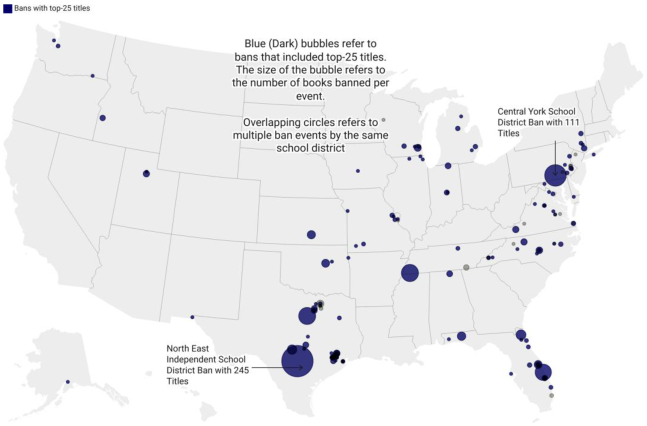

NOTE: figure/graphic rendered as an image from the PDF; its content is not machine-readable text. Caption (if any) follows as the next block.

*Note.* The figure shows the ban events where the top-25 titles are banned.

**Ananthakrishnan et al.:** *Book Bans in American Libraries* Marketing Science, 2025, vol. 44, no. 4, pp. 933–953, © 2025 The Author(s) 937

Page 7

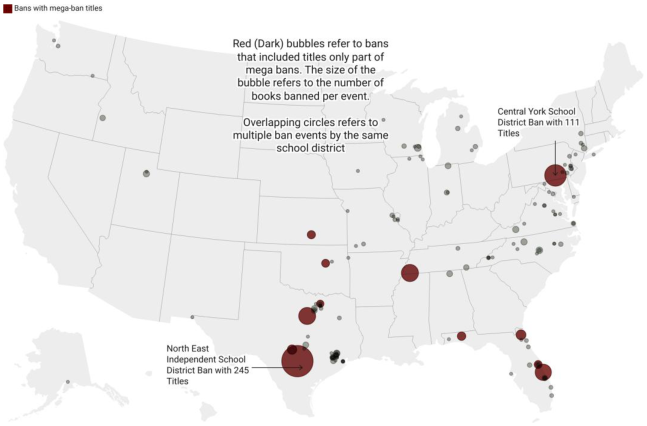

NOTE: figure/graphic rendered as an image from the PDF; its content is not machine-readable text. Caption (if any) follows as the next block.

key attributes that impact the attention received by any particular banned book. These top-25 titles are signifi cantly more likely to be “solo-banned”—that is, they were banned alone and not with any other books—are more likely to be banned with fewer other books on aver age and are likely to be banned simultaneously across states. This indicates that the top-25 titles in our sample do not need to share attention with other books and receive a lot of scrutiny in the media about the nature of the book, the content, and the reason why they are requested to be pulled off the shelves.

**Figure 2.** (Color online) Ban Coverage—Mega-Ban Titles

*Note.* The figure shows the ban events where titles that were banned only as part of mega-ban events are banned.

**Table 1.** Impact of Ban Events on Coverage

|  |  | Dependentvariables |
| --- | --- | --- |
|  | Log(NewsArticleCount) | Log(TweetCount) |
|  | All months Mega-ban months All months Mega-ban months |  |
| Variable | (1) (2) | (3) (4) |
| Top-25 | 0406*** 0484*** 0856*** 0961*** . . . . |  |
|  | (0136) (0162) . . | (0202) (0225) . . |
| Yearmonthfixedeffect | Yes Yes | Yes Yes |
| R2 | 007423 008157 . . | 008415 005637 . . |
| Observations | 4680 3276 , , | 4680 3276 , , |

NOTE: table converted from PDF layout to HTML text; cell boundaries are reconstructed. See PDF if exact alignment matters.

*Notes.* Robust standard errors clustered at the level of the title are in parentheses. The unit of observation is title-month. The dependent variable is log of news article count or tweet count per title per month. *Top-25* is an indicator variable which denotes if the title is a top-25 title or not. Columns (1) and (3) include all the months after October 2021 (the month when the first significant ban event occurred). Columns (2) and (4) include only those months after October 2021 which had a mega ban event.

**p <* 0.1; ***p <* 0.05; ****p <* 0.01.

**Ananthakrishnan et al.:** *Book Bans in American Libraries* 938 Marketing Science, 2025, vol. 44, no. 4, pp. 933–953, © 2025 The Author(s)

Page 8

United States, across different states, which might lead to higher awareness about these top-25 books as banned compared with the non-top-25 books. This analysis sug gests that our sample of book titles is more likely to be in the spotlight and become salient in the context of book bans happening around the country, which is important for market-level effects on consumption.

The books that we considered in our analysis were mainly in the fiction and nonfiction genres, covering topics or themes such as LGBTQ, Race, Diversity, etc., as identified by our data partner. Our Goodreads shelving data confirmed this, as seen in Table 2, col umn (2). Next, for each of these titles, we identify the months when the title was banned in a particular school district or public library using our banned book lists.<sup>14</sup> We also use a set of books to construct our con trol group(s). We elaborate on those steps after discuss ing the empirical framework.

**2.2.2. Goodreads Reviews Data.** As an alternative data source for social chatter, we use Goodreads, a popular cataloging website owned by Amazon with over 90 million members. We use this popular book review platform to identify reviews and numerical rat ings for each book in our sample. We also extract the review text (and, thus, the length of the review), the date the review was written, and the reviewer details for the period between January 2021 and June 2022. Goodreads also has a feature in which the date the user starts to read a book and the date that the user finishes a book are recorded for most reviews. In fact, some of these are automatically logged for books read on Kin dle. This also allows us to measure if there is a change in the time taken to read the books before and after the ban. Finally, we obtained details on the shelving or tag ging of books by readers (categories such as banned books, LGBTQ, etc.) to shed light on how people per ceive the topics of the book.

**2.2.3. Seattle Public Library Checkout Data.** To study how children consume banned books, we use de-identified patron level checkout data from the Seat tle Public Library. The Seattle Public Library (SPL) is among the top-25 public libraries in America, with a collection of over 2.4 million. The SPL has more than 17 million patron visits in the 27 branches, with an annual circulation of more than 12 million books.<sup>15</sup> Our data are available at the patron title date level for the period between January 1, 2021 and December 31, 2022 and contain information on the age group of the patrons.<sup>16</sup>

The SPL classifies patrons into different age groups, such as “Adults,” “Seniors,” “Young Adults,” and “Juniors,” depending on the birth date provided at the time of joining the SPL. Public schools in Seattle also allow schoolchildren to use their school ID to access SPL books. In this case, the age is coded as “Seattle Public School.” This does not include teachers because they are coded as “Seattle Public School Teachers.” We focus our analysis on Seattle and King County patrons and those whom the Seattle Public Library classifies as young adults (born between 2005 and 2009), juniors (born between 2010 and 2021), or from Seattle Public Schools (SPS checkouts).

To provide some descriptive evidence that young readers are potentially consuming these books, based on the literature (Agarwal and Sen 2022, Zhu et al. 2023), we collected additional Goodreads school shelf or tag data to identify a book’s relevance to school- related reading or educational purposes. In Table 2, column (3), we find that the top-25 titles in our main banned sample are shelved by Goodreads readers on school-related shelves (such as “K-8,” “pre-K” reading, “read with kiddos,” etc.) significantly more than the rest of the banned books in our sample. This provides us with some descriptive evidence of our top-25 titles’ readership among young readers.

**2.2.4. Political Campaign Emails Data.** To identify the issues that political candidates highlight in their cam paign communication strategies, we use political email data from the Democratic and Republican party candi dates. Political committees and candidates send regular campaign emails to individuals who subscribe to their mailing lists, highlighting the key issues of their politi cal strategies. We use a data set created by Derek Willis, who teaches journalism at the University of Maryland, by subscribing to mailing lists of various political can didates from across party lines.<sup>17</sup> Although the list of candidates is not exhaustive, the data can provide insight into strategies that politicians use to communi cate with their potential donors and voters, similar to other recent papers in the literature (Mathur et al. 2023). Within these emails, we focus on emails that refer to book bans or book ban-related keywords.<sup>18</sup>

Overall, our data contain emails from 245 unique email

**Table 2.** Shelving on Goodreads

|  |  | Dependentvariables |
| --- | --- | --- |
|  | Ban-Related | LGBTQ -Related School -Related |
| Variables | (1) | (2) (3) |
| Top-25 | 1845*** . | 7416*** 8718** . . |
|  | (793) . | (2838) (3668) . . |
| (Intercept) | 454** . | 5123*** 8130*** . . |
|  | (187) . | (671) (868) . . |
| R2 | 054901 . | 001511 001253 . . |
| Observations | 447 | 447 447 |

NOTE: table converted from PDF layout to HTML text; cell boundaries are reconstructed. See PDF if exact alignment matters.

*Notes.* The unit of observation is title. The dependent variable is the number of times a book is added to a particular shelf on Goodreads. *Top-25* is an indicator variable which denotes if the title is a top-25 title or not. Column (1) denotes ban-related shelves, column (2) denotes LQBTQ-related shelves, and column (3) denotes school-related shelves.

**p <* 0.1; ***p <* 0.05; ****p <* 0.01.

**Ananthakrishnan et al.:** *Book Bans in American Libraries* Marketing Science, 2025, vol. 44, no. 4, pp. 933–953, © 2025 The Author(s) 939

Page 9

IDs during the period between January 1, 2021 and December 31, 2022. Some of the most prominent accounts belonged to candidates such as Ron DeSantis, Jim Jordan, and Vivek Ramaswamy and PACs such as the 1776 Pro ject and the American Federation for Children. We found that 39 states were represented in our emails, with all 24 states that experienced bans as part of the 39. This implies that the emails’ text matched the locations where bans took place.

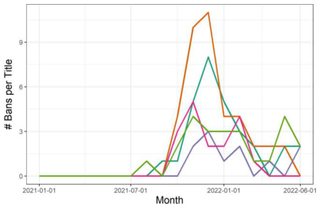

NOTE: figure/graphic rendered as an image from the PDF; its content is not machine-readable text. Caption (if any) follows as the next block.

**2.2.5. Political Contributions Data.** We identify individual-level contributions to all Republican and Democratic parties from the Federal Election Com mission’s (FEC’s) political donation data. We focus on all donations to candidates during the 2021–2022 elec tion cycle.<sup>19</sup> The data contain information on each donor’s home state, donation amount, and the party (also referred to as committee) with which the candi date is affiliated. We also use FEC candidate links to match a unique candidate with contributions to their committee.

**2.2.6. Twitter Data.** In our analysis, we also use social media data, focusing on Twitter. We use Brandwatch, a popular social media analytics platform<sup>20</sup> to fetch all the geotagged tweets from the United States that con tain the name of banned or control titles and their respective author names in the text of the tweet. For each tweet, we obtain the text, URL, Twitter user ID, follower count, location, and total impressions.<sup>21</sup>

To create a measure of social media visibility, we identify tweets that mention titles and their respective authors between January 2021 and July 2022 and clas sify titles with greater than the total median impres sions on Twitter as “High Visibility.” Additionally, to construct an alternate measure of author experience, we count all the tweets that mention the banned book authors’ names between January 2012 and December 2020. We then split the sample of authors into more experienced and less experienced authors based on the median count of tweets.

**3. Empirical Framework and Control Group 3.1. Empirical Framework** Although different books are banned at different times, the bans for each title continue to cascade after the first time a title is banned in any state, as shown in Figure 3 with the five most banned book titles.

Moreover, once a title gets banned in one state, local news media and social networks highlight ban events across the focal state, as well as nonfocal states that do not experience the bans, which can affect the demand for these titles in other states. Therefore, we define our treatment at the title level, and once a title is treated

(banned in the first state), it remains treated for the rest of our analysis.<sup>22</sup> Our identification relies on different titles being banned at different times, providing us with a staggered Difference in Differences (DiD) framework.

We estimate the DiD model using our main specifi cation shown in the following equation:

*yijt*  α*i* + γ*j* + τ*t* + β × *PostBanit* × *Bannedi* + *ɛijt*, (1)

where *PostBanit* is the event variable which takes a value of one if the month *t* is following the first time title *i* is banned in any state and zero otherwise.<sup>23</sup> For all control titles, the variable takes a value of zero for all months. *Bannedi* indicates whether the title *i* is in the list of books eventually banned. α*i*, γ*j*, and τ*t* capture fixed effects for title, state, and month, respectively. The coefficient of interest β captures the average impact of banning a title in any state on circulations. We use a four-month preperiod before the ban event and a six- month postperiod window.<sup>24</sup> The standard errors are clustered at the state level.

We verify the parallel trends assumption using the event study specification.

*yijt*  α*i* + γ*j* + τ*t* +

**equation / math rendering (image)**

NOTE: contains mathematical notation; text above is the PDF text layer and symbols may be mis-extracted. Image shows the original.

*m*4

**equation / math rendering (image)**

NOTE: contains mathematical notation; text above is the PDF text layer and symbols may be mis-extracted. Image shows the original.

β*m* × 1[*t ei*  *m*]

**equation / math rendering (image)**

NOTE: contains mathematical notation; text above is the PDF text layer and symbols may be mis-extracted. Image shows the original.

× *Bannedi* + *ɛijt:* (2)

The indicator variable 1[*t ei*  *m*] takes a value of 1 if the calendar month *t* is *m* months apart from the ban event *ei*. The baseline period is 1, which means that the average change in the circulations of banned titles compared with the circulations of control titles is mea sured relative to the difference in circulations one month before the ban. We use an array of estimators suggested in recent literature to account for potentially heterogeneous treatment effects in staggered DiD set tings to verify the robustness of the Two Way Fixed

**Figure 3.** (Color online) Number of Bans per Title

*Notes.* The figure shows the total number of ban events per title per calendar month for the five most banned books in our sample. Each line represents a title.

**Ananthakrishnan et al.:** *Book Bans in American Libraries* 940 Marketing Science, 2025, vol. 44, no. 4, pp. 933–953, © 2025 The Author(s)

Page 10

Effects (TWFE) estimates (Borusyak et al. 2021, Call away and Sant’Anna 2021, Sun and Abraham 2021).

It is pertinent to note that our broad empirical approach follows the intuition of studies in the litera ture that focus on the impact of salient events on con sumption behavior (Agarwal and Sen 2022, Wang and Lu 2022, Liaukonyt˙e et al. 2023). We also broaden the approach relative to these studies, which often analyze a single salient event. In particular, we use a range of event definitions to ensure robust results across the board. Although our conservative estimation approach uses the first ban event of a title as our main treatment event, we also analyze 127 title-state bans as events in our robustness analysis that significantly increase the number of events. At the other end of the spectrum, we also use the timing of the very first book ban event in our data as the sole event leading to a single event anal ysis, as in the studies above. Both of these approaches have their pros and cons. The drawback of using a sin gle event is that of external validity. The drawback of having a large number of events is the potential for spil lovers and overlapping time windows across events. Hence, by focusing on 25 title-level events, we believe we have taken a middle path while being grounded in both external validity and econometric logic.

**3.2. Control Group** We outline the logic behind identifying relevant books that might serve as an appropriate control group. From our partner, we acquired additional circulation data for books that could be part of the control group. Our first concern is to limit the spillovers of the treatment to the control books (Agarwal and Sen 2022). We also do not include books in the control group that have the same Book Industry Standards and Communications (BISAC) codes as banned books. The BISAC Subject Codes are standard categories used by publishing companies, booksellers, and libraries. BISAC Subject Codes represent a subcategorization of genres. For example, FIC049000 refers to books with African-American themes, and FIC022030 refers to mystery novels, even though both BISACs fall into the fiction genre. Therefore, when select ing a control group, we excluded books with the BISAC code FIC049000 but included books with the BISAC code FIC022030. We ensure that the circulations of the control books are comparable by selecting control books whose six-month preban period mean circulation is similar to that of the banned books. This process results in a set of 349 titles that form the control group, which does not contain the same themes or topics as the banned books (i.e., race and gender).

The construction of such a control group ensures that there is limited contamination bias. However, whether this serves as the right counterfactual could be questioned despite similar circulation levels. Hence, we use various other samples of control titles to check

the validity of our results. First, we restrict the current sample of control books to those belonging only to those genres that banned books belong to (i.e., fiction and nonfiction) and only to those genres that banned books do not belong to (i.e., business and economics), respectively. Second, we perform a check by automat ing the selection of control books using a propensity score matching approach (PSM). Finally, we also use books of the same BISAC Subject Codes as those of the banned books as a control group as part of the addi tional robustness exercises below. We elaborate on these results and other checks in the analyses below.

**4. Baseline Results and Heterogeneity 4.1. Baseline Results** First, we provide some model-free evidence of the impact of book bans on the circulation of treated and control group books. When we compare the normalized average monthly circulation during the preban and the postban period between control and the top-25 banned books, we observe that the average circulation of banned books has increased by 14.9% after bans compared with an increase in average circulation by just 0.8% for control books. However, the average effect might be confounded due to seasonality or state-specific factors, among others. Therefore, we employ a Difference-in-Differences model to provide a causal estimate of the impact of book ban events on circulations.

In the main results, we first begin by analyzing the entire set of 468 banned books in our data. In Table 3, column (1), we find a small, marginally statistically sig nificant effect of book bans on readership for the entire sample. We then split the sample into the top-25 titles (column (2)) and the rest (column (3)) to find that the top-25 titles experience a strong positive effect of bans, whereas the rest experience precisely estimated null effects.<sup>25</sup> In column (4), we also present the results for the whole sample but with the number of bans as a continuous interaction variable. As can be seen, the impact on circulation increases with the number of times a book is banned. Given that our main sample of the top-25 banned titles from PEN America and ALA drive our main effects, we focus on this particular sam ple, following the strategy of Agarwal and Sen (2022).

**Ananthakrishnan et al.:** *Book Bans in American Libraries* Marketing Science, 2025, vol. 44, no. 4, pp. 933–953, © 2025 The Author(s) 941

Page 11

Note that any library circulation change in percent age or absolute terms is a conservative lower bound when we attempt to understand the economic signifi cance of these estimates. This is because both physical and electronic circulation is limited by existing inven tory, limiting how high demand can go. This issue is similar in spirit, for example, to online rental market places for clothes (Kan et al. 2024) and short-term stays (Zhang et al. 2022). Moreover, these books borrowed

from school and public libraries often cater to a broader community, such as a classroom, as noted in Agarwal and Sen (2022). Unfortunately, we cannot report units for the circulation data because it is proprietary infor mation. We can say that postban, the increase in circu lation itself puts the title in the 90th percentile of most circulated books in our broader data set. Additionally, based on some publicly available estimates, we can say that the increase in circulation over the six months after the book ban surpasses the lifetime sales of the average book published in the United Sates. We also interpret

**Table 3.** All Titles: Impact of Ban Events on Circulation

|  |  | Dependentvariable |  |
| --- | --- | --- | --- |
|  |  | Log(Circulation) |  |
|  | Alltitles | Top-25 titles Non-top-25 titles | Impactperban |
| Variables | (1) | (2) (3) | (4) |
| PostBan×Banned | 0016* . | 0113*** 0011 . . | 0009 . |
|  | (0009) . | (0017) (0009) . . | (0009) . |
| PostBan×Banned×IntensityofBan |  |  | 0018*** . |
|  |  |  | (0002) . |
| Statefixedeffect | Yes | Yes Yes | Yes |
| Titlefixedeffect | Yes | Yes Yes | Yes |
| Yearmonthfixedeffect | Yes | Yes Yes | Yes |
| R2 | 062819 . | 057637 062452 . . | 062831 . |
| Observations | 421382 , | 249660 411122 , , | 421382 , |

NOTE: table converted from PDF layout to HTML text; cell boundaries are reconstructed. See PDF if exact alignment matters.

*Notes.* Robust standard errors clustered at the level of the state are in parentheses. The unit of observation is state-title-month. The dependent variable is the log of circulation. Columns (1) and (4) use all the banned books, column (2) uses only the top-25 most banned books, and column (3) uses all the banned books except the top-25. Column (4) uses the monthly cumulative count of bans as the interaction variable.

**p <* 0.1; ***p <* 0.05; ****p <* 0.01.

**Table 4.** Impact of Ban Events on Circulation

|  |  |  | Dependentvariable |  |  |
| --- | --- | --- | --- | --- | --- |
|  |  |  | Log(Circulation) |  |  |
|  | All | Banned | Nonbanned Author Twitter | Blue | Red |
|  | States | States | States Experience Visibility | States | States |
| Variables | (1) | (2) | (3) (4) (5) | (6) | (7) |
| PostBan×Banned | 0113*** . | 0118*** . | 0106*** 0005 0015 . . . | 0119*** . | 0107*** . |
|  | (0017) . | (0022) . | (0029) (0020) (0021) . . . | (0023) . | (0026) . |
| PostBan × Banned × Less-experienced Author |  |  | 0229*** . |  |  |
|  |  |  | (0031) . |  |  |
| PostBan×Banned×HighVisibility |  |  | 0206*** . |  |  |
|  |  |  | (0036) . |  |  |
| Statefixedeffect | Yes | Yes | Yes Yes Yes | Yes | Yes |
| Titlefixedeffect | Yes | Yes | Yes Yes Yes | Yes | Yes |
| Yearmonthfixedeffect | Yes | Yes | Yes Yes Yes | Yes | Yes |
| R2 | 057637 . | 055644 . | 061870 057647 057645 . . . | 052521 . | 064069 . |
| Observations | 249660 , | 151110 , | 98550 249660 249660 , , , | 131400 , | 118260 , |

NOTE: table converted from PDF layout to HTML text; cell boundaries are reconstructed. See PDF if exact alignment matters.

**p <* 0.1; ***p <* 0.05; ****p <* 0.01.

**Ananthakrishnan et al.:** *Book Bans in American Libraries* 942 Marketing Science, 2025, vol. 44, no. 4, pp. 933–953, © 2025 The Author(s)

Page 12

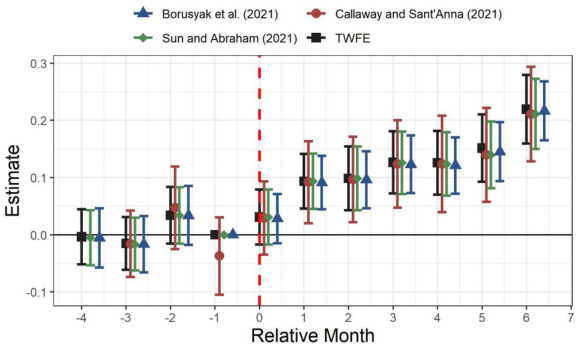

NOTE: figure/graphic rendered as an image from the PDF; its content is not machine-readable text. Caption (if any) follows as the next block.

the estimates’ economic significance differently by nor malizing circulation numbers by the pretreatment cate gory level mean and the pretreatment title level means. The result shown in Table A4, column (3) in the Online Appendix indicates that, on average, the increase in cir culation in the postban period is 0.32 times (or 32% of) the mean circulation of all the books in their respective categories. Results are shown in Table A4, column (4) in the Online Appendix. Our results indicate that, on average, the increase in circulation in the postban period is 0.46 times (or 46% of) the mean circulation of a title in the preban period.

Figure 4 shows the event study estimates using the TWFE estimator and the three recently developed

estimators by Borusyak et al. (2021), Sun and Abraham (2021), and Callaway and Sant’Anna (2021). There are a few clear takeaways. First, we find no significant changes between the treated and control groups in the preperiod, verifying the parallel trends assumption. The parallel trends assumption holds not only for the TWFE estimator, but also for three other popular esti mators that explicitly account for the staggered nature of the treatment. Second, there is a statistically signifi cant jump in the circulation numbers of banned titles relative to control books after banning a title in any state. Overall, these results give us confidence in the credibility of our results. We present the average esti mates for these three alternative methods in Table 5,

**Figure 4.** (Color online) Event Study Estimates

*Notes.* The figure shows event study estimates using four different estimation methods. The dependent variable is the log of circulation. The unit of observation is at the title-state-month level. 95% confidence intervals are shown.

**Table 5.** Additional Estimators: Impact of Ban Events on Circulation

|  |  |  |  | Dependentvariable |  |  |
| --- | --- | --- | --- | --- | --- | --- |
|  |  |  |  | Log(Circulation) |  |  |
|  | Callaway | Sun& | Borusyak | Population- | Complete | Nospillover |
|  | Sant’Anna | Abraham | et al . | weightedTWFE | spilloverTWFE | TWFE |
| Variables | (1) | (2) | (3) | (4) | (5) | (6) |
| PostBan×Banned | 0114*** . | 0115*** . | 0115*** . | 0149*** . | 0084*** . | 0300*** . |
|  | (0022) . | (0020) . | (0017) . | (0022) . | (0020) . | (0069) . |
| Statefixedeffect | Yes | Yes | Yes | Yes | Yes | Yes |
| Titlefixedeffect | Yes | Yes | Yes | Yes | Yes | Yes |
| Yearmonthfixedeffect | Yes | Yes | Yes | Yes | Yes | Yes |
| R2 |  | 057673 . |  | 065015 . | 059632 . | 054692 . |
| Observations | 249660 , | 249660 , | 249660 , | 249660 , | 156750 , | 146133 , |

NOTE: table converted from PDF layout to HTML text; cell boundaries are reconstructed. See PDF if exact alignment matters.

*Notes.* Robust standard errors clustered at the level of the state are in parentheses. The unit of observation is state-title-month. The dependent variable is the log of circulation. Column (1) uses Callaway and Sant’Anna (2021), column (2) uses Sun and Abraham (2021), and column (3) uses Borusyak et al. (2021) instead of the TWFE estimator. Column (4) shows average estimates using TWFE estimator with state population weights. Columns (5) and (6) show average estimates for alternate event identification assumptions.

**p <* 0.1; ***p <* 0.05; ****p <* 0.01.

**Ananthakrishnan et al.:** *Book Bans in American Libraries* Marketing Science, 2025, vol. 44, no. 4, pp. 933–953, © 2025 The Author(s) 943

Page 13

columns (1)–(3).<sup>26</sup> In Table 5, column (4), we also repli cate our main estimate with a population-weighted regression, using state-level weights, to find qualita tively and quantitatively similar results.

Overall, these results imply that these book bans tar geted at individual public libraries or school districts lead to a Streisand effect more generally, rather than a potential chilling effect. A caveat is that we do not observe circulation at the school or public library level. Hence, we cannot shed light on the reading behavior in the locations that felt the direct consequences of the ban.

**4.2. Robustness Checks** In this section, we explore whether our results are robust on several different dimensions.

As discussed above, spillovers could be from one banned book to another. In a different setting, Borah and Tellis (2016) show that negative chatter about a product can have a spillover effect and impact the con sumption of related products. We use two different measures to test the spillover of book bans on the circu lation of related books. First, we test whether there are spillovers to books of similar genres, as defined by the same BISAC codes of the banned books. Next, we look

at spillovers into other books written by the same author who wrote the banned book. As can be seen from Table A2, columns (1)–(3) in the Online Appen dix, we do not observe spillover effects of book bans on circulations of books with similar genres or other books authored by authors of banned books.

**4.2.2. Alternative Control Groups.** To verify the valid ity of our results for the selection of alternate control groups, we perform additional checks using multiple different selections of control book titles. First, we restrict our original control group books to only those genres (such as fiction and nonfiction) in which banned books appear. Second, we limit the original control group books to only those genres in which banned books do not appear (such as business and economics). This exercise ensures that our results are not influenced by similarity or dissimilarity to the control group books. Table 6, columns (5) and (6), as well as Figure 5 show that the event study estimates are similar to the estimates that use the original control group. Third, instead of using a control group of books with unre lated BISAC Subject Codes, we use books with the same BISAC Subject Codes as those of the banned books to create the control group. This exercise ensures that we compare banned book circulation to the circu lation of similar, but not-banned, books. Additionally, we also use the matching approach to choose control titles with the same BISAC Subject Codes as those of the banned books. Results shown in Table 6, columns (7) and (8) illustrate the robustness of the treatment effect to these additional subsets of control group titles.

We provide further evidence of the robustness of our results to the choice of control group books in Table A3 in the Online Appendix, where we replicate the whole of Table 4, and Figure A4 in the Online Appendix that replicates Figure 4 using propensity score matching. Instead of limiting the choice set of control books our selves, we use a matching technique to identify a group of control books from the entire sample of books that are not of the same BISAC Subject Codes as those of the banned books. Using propensity score matching, we match the six-month preban period mean circulation and the genre of control books to that of the banned books and identify a set of 25 control books. This method ensures that the control group is similar to that of the banned books in terms of preperiod circulation and genre. Our results show that the choice of control titles has a minimal effect on the impact of bans on banned book circulation.

**4.2.3. Additional Robustness Checks.** We perform several additional robustness checks to verify the valid ity of our results. To ensure that our results are robust to alternative functional forms of the dependent vari able, we re-estimate the model using inverse hyperbolic

sine transformation of circulations as the dependent variable to find the results qualitatively similar, as seen in Table A4, column (1) in the Online Appendix. We find similar results in column (2) when using a negative binomial model specification instead. We also repeat the analysis using quarter- and quarter-state fixed effects to account for the potential increase in state-level reading trends driven by organic growth of interest in reading banned books, and we find no change in our estimates (column (3)). To ensure no selection into treatment, we conduct a falsification analysis, where we randomly assign the treatment date to each banned title between

January and June 2021 to find null results (column (4)). Finally, to verify that the choice of preperiod length does not influence our results, we repeat the analysis using a preperiod of six months instead of four months to find qualitatively similar results (column (5)).<sup>28</sup> To ensure that our results are not driven by any one partic ular title, we carried out two sets of leave-one-out analy ses. In the first one, we replicated the baseline average effect by leaving out one title at a time. Figure A6 in the Online Appendix shows that average effects remain sta tistically significant (at the 5% level) and similar in mag nitude to our full sample estimate. Next, we also carried out the same leave-one-out analysis but for the heteroge neity analysis and report the triple interaction coeffi cients in Figure A7 in the Online Appendix to find that the results are qualitatively and quantitatively similar to the estimates when all books are included.

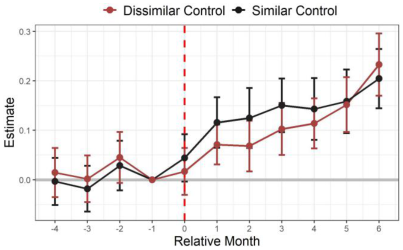

NOTE: figure/graphic rendered as an image from the PDF; its content is not machine-readable text. Caption (if any) follows as the next block.

**Figure 5.** (Color online) Impact of Book Bans on Circulation—Alternate Control Books

*Notes.* The figure shows event study estimates using the TWFE esti mator with the log of circulation as the dependent variable. It plots the estimates along with the 95% confidence intervals using control group books similar to banned books (top) and control group books dissimilar (bottom) to banned books separately.

**Table 6.** Additional Robustness: Impact of Ban Events on Circulation

|  |  |  |  | Dependentvariable |  |  |  |
| --- | --- | --- | --- | --- | --- | --- | --- |
|  |  |  |  | Log(Circulation) |  |  |  |
|  |  | Alternate |  |  | Different | Banned | Matched |
|  | AlternateFirst | Author | Banned | Nonbanned SameGenre | Genre | BISAC | BannedBISAC |
|  | BanMonth | Experience | RedStates | RedStates Controls | Controls | Controls | Controls |
| Variables | (1) | (2) | (3) | (4) (5) | (6) | (7) | (8) |
| PostBan×Banned | 0088*** . | 0030 . | 0121*** . | 0071 0128*** . . | 0082*** . | 0120*** . | 0095*** . |
|  | (0018) . | (0025) . | (0029) . | (0060) (0018) . . | (0014) . | (0019) . | (0017) . |
| PostBan×Banned |  | 0161*** . |  |  |  |  |  |
| × Less-experienced Author |  | (0031) . |  |  |  |  |  |
| Statefixedeffect | Yes | Yes | Yes | Yes Yes | Yes | Yes | Yes |
| Titlefixedeffect | Yes | Yes | Yes | Yes Yes | Yes | Yes | Yes |
| Yearmonthfixedeffect | Yes | Yes | Yes | Yes Yes | Yes | Yes | Yes |
| R2 | 057618 . | 057642 . | 064999 . | 043352 061063 . . | 064579 . | 058258 . | 073088 . |
| Observations | 249812 , | 249660 , | 85410 , | 32850 101232 , , | 41724 , | 434340 , | 34884 , |

NOTE: table converted from PDF layout to HTML text; cell boundaries are reconstructed. See PDF if exact alignment matters.

*Notes.* Robust standard errors clustered at the level of the state are in parentheses. The unit of observation is state-title-month. The dependent variable is the log of circulation. Column (1) uses the month of first ban as the event instead of the month following the first ban. Column (2) includes an alternate measure of author experience as an interaction variable. Columns (3) and (4) show the average treatment effect in Red states with at least one ban event and no ban events, respectively. Columns (5) and (6) show the average treatment effect with control book titles with a subset of genres. Columns (7) and (8) show the average treatment effect with control book titles that have the same BISAC Subject Codes as those of banned books. Column (8) uses control book titles obtained by the Propensity Score Matching technique.

**p <* 0.1; ***p <* 0.05; ****p <* 0.01.

**4.3. Heterogeneous Impact of Book Bans** We look at several dimensions of heterogeneity to understand the potential mechanisms driving the base line results above.

**4.3.1. Author Experience.** First, we try to understand whether the average effects vary with the author’s experience. Studies in the literature (Petrova et al. 2021) suggest that media coverage could have an information or persuasive effect. In particular, Petrova et al. (2021) show that (social) media helps new players on the mar ket because of the information effect. To construct a measure of experience, we use the total number of books the author wrote before the book ban, excluding the banned book. We categorize the authors in our trea ted sample as more experienced and less experienced authors based on the median count of books and esti mate Equation (1) with author experience as an interac tion variable. The results, shown in Table 4, column (4), reveal that titles by less experienced authors drive the impact of book bans on circulation. Figure 6(a) shows the event study estimates using subsample analyses. We see no impact of book bans on books written by more experienced authors, whereas there is a significant increase in the circulation of books by less experienced authors following bans. We also use social media visi bility as an alternate measure of author experience. We count all tweets that mention the names of banned authors between January 2012 and December 2020. We then split the sample of authors into more-experienced and less-experienced authors based on the tweet counts. Our results, shown in Table 6, column (2), are consistent with the measure of the author’s experience from Good reads data.

**4.3.2. Social Media Visibility.** Social media has played a key role in cultural debates and in driving local and wider national conversations around book bans. To understand the potential role of Twitter in explaining our findings, we repeat the main analyses using visibil ity on Twitter as an interaction variable. Results in

**Figure 6.** (Color online) Heterogeneous Impact of Book Bans on Circulation

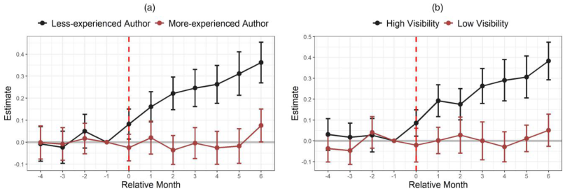

NOTE: figure/graphic rendered as an image from the PDF; its content is not machine-readable text. Caption (if any) follows as the next block.

*Notes.* Panel (a) shows event study estimates using the TWFE estimator. It plots the estimates along with the 95% confidence intervals for banned book titles by less-experienced (top) and more-experienced authors (bottom) separately. Panel (b) plots the estimates along with the 95% confi dence intervals for banned book titles with high (top) and low (bottom) Twitter visibility separately. (a) By author experience. (b) By Twitter visibility.

Table 4, column (5) show that the effect of book bans is driven significantly by titles with high visibility (titles with more than the median number of impressions) on Twitter. Figure 6(b) shows the estimate of the event study using subsample analyses. Books with low Twit ter visibility did not see an impact of ban events, whereas books with high Twitter visibility saw a signif icant increase in circulation following bans.

These results on social media chatter, along with those on author experience, suggest that conversations about inexperienced authors can provide information and impact consumer decisions. The fact that even within these 25 books that were banned more than 300 times, the only books that see an increase in circulation are those that are discussed on social media highlights the critical role of new media in the context of polariz ing issues. It highlights that the critical mechanism that leads to any impact of such book bans is the spread of information; otherwise, it has a null effect on consumer behavior.

Next, we carry out a check to rule out reverse causal ity with social media chatter leading to book bans in the first place. In particular, we estimate the same regression model as in Equation (1) but use Twitter engagement (tweet counts and impressions) as the dependent variable instead of circulation numbers. The results in Figure 7 demonstrate two clear points. First, there is no significant pretrend in social media chatter or engagement between the banned and the control books prior to the ban. Second, after the ban, Twitter chatter and engagement with banned books increased significantly relative to the control books. Given the lack of pretrends, it is unlikely that increased social media mentions leading to the book bans.<sup>29</sup>

To dig further into the mechanism behind the increase in circulation, we analyzed the news coverage of each of the 142 district-month level book ban events to identify

whether a national or local news outlet first covered the story. To do so, we obtained the top 100 articles on a Google News search with the school district name, ban timing, and state name. We manually verified and classified all the news stories as local or national outlets/organizations (such as PEN America, the ALA, the American Civil Liberties Union, or the National Coa lition Against Censorship). In only five cases was the first article about the ban event written by a national news outlet (e.g., CNN, *The Wall Street Journal*, *The New York Times*, USA Today, etc.). In all other cases, the story was *first* covered by a local news outlet. There was also a distinct difference in how the local and national news reported the stories. Specifically, local news outlets focused on the *particular district or library* where the ban was enacted and interviewed local students, parents, and educators. However, national news outlets talked about book bans more generally as a rising national trend and mentioned the bans by combining several bans as examples of these trends. We show the news coverage of bans descriptively month-on-month around the time of the ban in Figure 8 to see a spike in news cov erage after a ban was in place, with the bulk of the cover age driven by local news outlets. We break this coverage down by differentiating between local news outlets of the focal state where the ban occurred (for example, a local newspaper covering a county in Pennsylvania talk ing about a book ban in that county it serves), national news coverage, and nonfocal local news outlets (these refer to local newspapers that refer to book bans hap pening outside their state). Figure 8 also shows that local news outlets in the focal state are more likely to cover these events than other local outlets and are equally likely relative to national news outlets. These numbers highlight the emphasis provided by local outlets in the focal state and align with the narrative of the initial buzz being generated locally but then being picked up more

**Figure 7.** (Color online) Event Study Estimates for Twitter Chatter

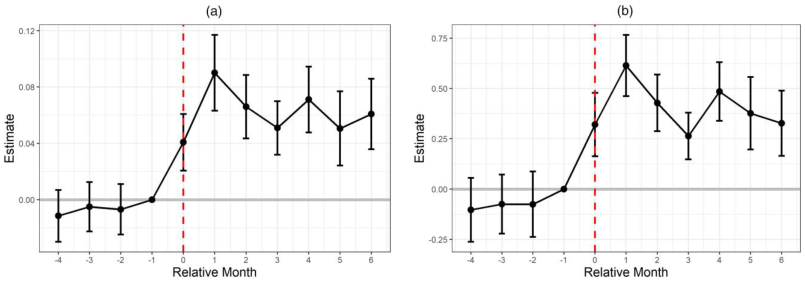

NOTE: figure/graphic rendered as an image from the PDF; its content is not machine-readable text. Caption (if any) follows as the next block.

*Notes.* Panel (a) shows the TWFE event study estimates with log of tweet counts as the dependent variable. Panel (b) shows TWFE event study estimates with log of tweet impressions as the dependent variable. 95% confidence intervals are shown. (a) Tweet counts. (b) Tweet impressions.

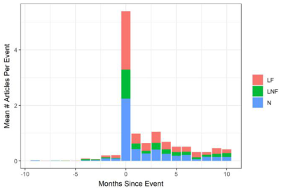

NOTE: figure/graphic rendered as an image from the PDF; its content is not machine-readable text. Caption (if any) follows as the next block.

generally, leading to a larger effect in the focal state but also positive spillovers onto other states that didn’t see a ban. This finding is also intuitive because book bans orig inate in local school board meetings and are very much a local issue. Further, this points to the fact that book bans become interesting nationally only when enough of them appear as a rising trend worth reporting.<sup>30</sup>

Finally, to provide additional evidence on the role of social media chatter, we also analyze data from Good reads. We find that after ban events, there is an increase in the number of reviews written, the number of reviews mentioning book bans explicitly, and the aver age rating of the banned books relative to the control. We provide details of these results in Table A6 in the Online Appendix.

**4.3.3. Blue vs. Red States.** Books bans have become a prominent part of politically polarizing “culture wars.” Politicians have actively used these issues as part of election campaigns. Therefore, there could be a politi cal dimension to who reacts to these book bans. Using the electoral outcomes of the 2020 presidential election, we classify each of the 38 states as Blue (if the majority vote in the state was for Joe Biden in the 2020 elections) or Red (if the majority vote in the state was for Donald Trump in the 2020 elections). Overall, our data have 20 Blue states and 18 Red states. Given that our circulation data are at the title-state-month level, we use state-level measures of political preferences for this analysis. Table 4, columns (6) and (7) show that the impact of book bans can be seen both in the Blue and Red states, respectively. The average effect is 11% higher in the Blue states. In Table 6, columns (3) and (4), we show that for the Red states, the circulations of banned books have increased only in the states with book bans.

However, among Blue states, the circulation of banned books has increased in states with and without bans.

**4.4. Impact on Children’s Reading Behavior** Our primary data do not distinguish reading behavior between adults and children. To provide evidence that the increased consumption might also include children reading more banned books, we use de-identified patron- level checkout data from the Seattle Public Library. These data provide unique insight into children’s reading behavior in the aftermath of book bans in different parts of the United States.

We aggregate the data at the patron-title-month level in our analyses. Out of the 25 banned books from our sample, we matched 24 titles from the SPL checkout data. To create a control group of titles, we remove books dealing with subjects similar to the banned titles and whose preban circulation trends are similar to those of the banned books. Overall, we have 24 banned titles and 76 control titles. Our consultation with the SPL revealed that parents would often check out books on behalf of their children. We use only patrons who are identified as children, which ensures that our results are conservative.

We estimate the causal impact of book bans on children’s reading behavior using the staggered DiD model shown in Equation (1), where *yit* refers to the cir culation count of title *i* at month *t*. Because we use data that only pertain to the SPL, we drop the subscript *j*. Table 7, column (1) shows that, on average, children read banned books about 19% more than the control books following book ban events. These magnitudes are in the ballpark of the magnitudes we find across different specifications in the aggregate analysis. We further classify the patrons as inclusive content readers and inclusive content nonreaders based on whether they read any books dealing with race and/or gender identity in the preban period (between January 2021 and June 2021). Our results, shown in columns (2) and (3), indicate that the increase in banned book circula tion is driven by patrons who have not yet been exposed to inclusive content. Our results suggest that book bans expose “new” readers among children to inclusive subject matter in libraries, furthering our belief that book bans end up increasing the salience of the books that they aim to ban. We also use an alternate identification specification, based on the single event difference in differences, to highlight the robustness of our results, as shown in column (4).

Overall, these results suggest that children began to read more of these banned books after they were banned in different parts of the United States. This analysis sheds some light on the mechanisms behind the aggregate results presented previously. These results come with the caveat that the data are based on patron-level data from one city’s public library

**Figure 8.** (Color online) Number of News Articles

*Notes.* The figure shows the mean number of news articles covering a ban event each month relative to the month of the event. The news articles are classified as local newspapers covering a focal state event (LF), local newspapers covering a nonfocal state event (LNF), and national newspapers covering the event (N).

system. However, we believe that these data provide unique insight into the reading behavior of children that are hard to come by otherwise.<sup>31</sup>

**4.5. Alternate Measure of Consumption: Amazon Sales Rank Data** We use Amazon sales rank data from Keepa for each book every month as an alternate book consumption measure to add credence to our results. Such sales rank data have been widely used in the literature previously (Reimers and Waldfogel 2021) and from Keepa in particular—for example, by Socal et al. (2024). We run the same difference-in-differences estimation but with log sales rank as the outcome variable. The results reported in Figure 9 show parallel trends in the preper iod and then a reduction in the sales rank of the treated

books relative to the control group. There is a 41% (exp(0.53) 1) decline in sales rank, implying a signifi cant increase in sales. Although it is not straightforward to interpret these sales rank changes because of potential nonlinearities in the sales and sales rank link, we can benchmark against other sales rank estimates in the liter ature. For example, Reimers and Waldfogel (2021) find that a book’s Amazon sales rank improves by 78% in the five days after a *New York Times* review is published. We believe that our magnitudes are economically significant relative to this benchmark. We do not have sales data on quantities to convert these sales-rank changes into unit changes. However, we can use some publicly available tools<sup>32</sup> to convert Amazon sales rank changes into abso lute quantities. Using this, we find that the number of copies sold per month would have increased from 90 to 360 on Amazon alone. We report these magnitudes with the caveat that we do not know the underlying model this company uses to translate sales rank to units.

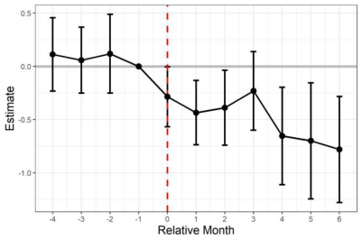

NOTE: figure/graphic rendered as an image from the PDF; its content is not machine-readable text. Caption (if any) follows as the next block.

**5. Book Bans and Political Rhetoric** The above analysis shows that book bans targeted at microgeographic levels can lead to media attention on those particular books and, in turn, increase reader ship. We also find that this readership can increase in both Democratic and Republican states. As mentioned previously, politicians have used the recent surge in book ban attempts to gain an electoral advantage over their competitors.<sup>33</sup> In this section, we attempt to dig deeper into the political dimension of these bans and quantify whether politicians gain in any way from these issues. In particular, similar to Petrova et al. (2021), we analyze how these book bans feature in political rhetoric and might be associated with political donations received by politicians.

**Table 7.** Impact of Ban Events on Circulation

|  |  | Dependentvariable |  |
| --- | --- | --- | --- |
|  |  | Log(Circulation) |  |
|  | All | Inclusive Inclusive | Alternate |
|  | Readers | Readers Non-Readers | Identification |
| Variables | (1) | (2) (3) | (4) |
| PostBan×Banned | 0189*** . | 0061 0166*** . . | 0279*** . |
|  | (0059) . | (0055) (0054) . . | (0066) . |
| Titlefixedeffect | Yes | Yes Yes | Yes |
| Yearmonthfixedeffect | Yes | Yes Yes | Yes |
| R2 | 046983 . | 040276 034480 . . | 051134 . |
| Observations | 2088 , | 2088 2088 , , | 1100 , |

NOTE: table converted from PDF layout to HTML text; cell boundaries are reconstructed. See PDF if exact alignment matters.

*Notes.* Heteroskedasticity-robust standard errors are in parentheses. The unit of observation is title-month. The dependent variable is log of circulation. *PostBan* is an indicator variable which denotes if the time period is after the month following the first time the title is banned in any state. *PostBan* is zero for all control titles. Column (1) includes all the readers, column (2) includes only those readers who checked out inclusive titles, and column (3) includes only those readers who did not check out inclusive titles. Column (4) shows average estimates for an alternate event identification assumption.

**p <* 0.1; ***p <* 0.05; ****p <* 0.01.

**Figure 9.** (Color online) Impact of Book Bans on Amazon Sales Rank

*Notes.* The figure shows the TWFE event study estimates with log of Amazon Sales Rank as the variable of interest. The 95% confidence intervals are shown.

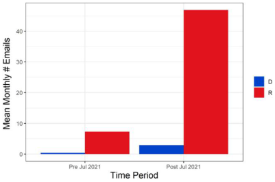

NOTE: figure/graphic rendered as an image from the PDF; its content is not machine-readable text. Caption (if any) follows as the next block.

First, we examine how book bans feature in political candidates’ communication strategies. We do this by analyzing the text of emails sent to potential donors who subscribe to campaigns of political candidates and committees. We identify book ban-related emails using keywords such as “banned books,” “book challenges,” “book censorship,” etc. Figure 10 shows that before the first book bans in our sample, a small number of emails from Republican candidates mentioned any book ban- related topic. After the first book bans in our sample, there was a significant increase in emails sent out by Republican candidates and committees referring to book bans.<sup>34</sup> Furthermore, as shown in the figure, this increase is seen mainly for Republican candidates and committees rather than their Democratic counterparts. Overall, more than 90% of the emails were from politi cians in the Republican party, even though bans

occurred in the Red and Blue states. A caveat in inter preting these results is that we have a selected sample of 245 political accounts, and, hence, generalizations should be made with caution.

Next, we want to understand whether politicians enjoy any political benefit from these book bans. In par ticular, we want to examine whether such events bene fit Democrats or Republicans, if at all. To identify the potential association of book ban events with political donations, we compare political contributions to Dem ocratic and Republican House candidates before and after the first book ban in each state to which the candi date belongs. In line with Petrova et al. (2021), our anal ysis focuses on small donations potentially influenced by these communications, specifically examining con tributions under $500 each.

The results shown in Table 8 provide a nuanced pic ture. In column (1), we see no differential association of ban events with donations received by Republican politicians relative to Democrats. In column (2), focus ing on the Blue States (based on their vote for Joe Biden), we find that this null effect in the difference between the Republican and Democratic donations persists. Column (3) provides suggestive evidence in line with a concerted political strategy. In particular, in the Red States, Republican candidates get a significant increase in political donations relative to their Demo crat counterparts. Economically, the estimates suggest a 30% increase in donations under $500 for Republican politicians relative to Democrat candidates. In absolute terms, the average Republican gets $800 (mean is $2,668) more every month after book ban events.

Overall, this analysis provides suggestive evidence for why some Republican politicians might favor book bans. Although such book bans increase circula tion, Republican politicians in the Red States that see bans seem to gain donations relative to Democratic

**Figure 10.** (Color online) Mean Monthly Emails Containing Ban-Related Keywords

*Note.* The figure shows the average number of campaign emails sent per month by Democratic and Republican party candidates before and after the first book ban event.

**Table 8.** Impact of Ban Events on Political Donations

|  |  | Dependentvariable |  |
| --- | --- | --- | --- |
|  |  | Log(Donations) |  |
|  | AllStates | BlueStates | RedStates |
| Variables | (1) | (2) | (3) |
| PostBan×Republican | 0084 . | 0155 . | 0305** . |
|  | (0201) . | (0360) . | (0132) . |
| Statefixedeffect | Yes | Yes | Yes |
| Candidatefixedeffect | Yes | Yes | Yes |
| Year-month fixed effect | Yes | Yes | Yes |
| State × year-month fixed effect | Yes | Yes | Yes |
| R2 | 068125 . | 067531 . | 068087 . |
| Observations | 16405 , | 8012 , | 8393 , |

NOTE: table converted from PDF layout to HTML text; cell boundaries are reconstructed. See PDF if exact alignment matters.

*Notes.* Robust standard errors clustered at the level of the state are in parentheses. The unit of observation is candidate-month. The dependent variable is the log of the donation amount. Column (1) uses all the banned states, and columns (2) and (3) use only Blue and Red banned states, respectively.

**p <* 0.1; ***p <* 0.05; ****p <* 0.01.

candidates. A caveat is that this analysis does not entirely establish causality and should be seen as descriptive and as a first step in understanding the politics around book bans.

**6. Discussion and Conclusions** Although book bans have been occurring at increased frequencies in the past couple of years, there is limited causal evidence of their impact. In this study, we pre sent the first evidence of book ban events on book cir culations, as well as their political implications. Using novel data on book circulation, we show that book bans increase the circulation of banned books by 12% compared with other books. This effect is persistent in states with bans and states without bans, though the effect is larger in focal states experiencing bans. Author experience and social media visibility play a significant role in driving this impact—titles by less-experienced authors and titles with high visibility on Twitter see sig nificantly higher circulations following bans. Finally, Republican Party candidates use these contentious book bans as part of their political rhetoric in emails to donors, which is associated with an increase in small donations, particularly in the Red States.

Our results have significant managerial and policy implications. Firstly, we highlight the impact of politically motivated censorship on consumers’ consumption behav ior. Despite the increasing incidence of book bans in schools and public libraries, bans create a “Streisand” effect on consumption, where politically motivated consu mers increase the consumption of banned books. This finding has takeaways for content creators and publishers. This has long-term implications because microlevel bans may create a chilling effect among creators who produce diverse content, which might be detrimental to consumers of such content by furthering the underrepresentation of such content. Our results suggest that such bans at the microlevel may not hinder overall demand. We also high light the importance of social media visibility in driving political conversations around sensitive issues. Stake holders should be aware of the potential of social media to magnify political beliefs and thereby influence con sumption decisions on a large scale. Finally, stakeholders should also be mindful of the feedback loop, where pursu ing contentious policies can lead to more polarized rhetoric through campaign emails, leading to an increase in financial support for politicians, which can further incentivize pursuing contentious policies.

Our empirical results come with caveats regarding external validity. First, we focus on the 25 most banned titles that account for 127 titles × state events that are the most salient events. For other titles, we find a null result. Hence, the main analysis might only apply to high-profile titles that get significant attention on social and traditional media, which might be a different

treatment relative to less prominent events. Next, our political emails analysis is not based on comprehensive data, but on 245 accounts for which the data are curated as a public good. Going forward, it could be important to analyze the digital messaging strategy of a more representative set of politicians in the wake of such book bans. Finally, we do not have comprehen sive data on children’s reading behavior because of pri vacy regulations and need to rely on data from one public library system along with inferred data from Goodreads.

More broadly, our research also opens avenues for further research. First, although we observe an increase in circulations after bans in the short term, the long- term implications remain uncertain. With increased political polarization, there is the possibility that librar ians and educators, anticipating possible future bans, may choose not to stock or assign such books.<sup>35</sup> Fur thermore, we do not measure the impact on beliefs and attitudes of adults and children that might evolve slowly and see a change in the longer term. Second, the book bans in our sample happen at the public library or school district level, and our circulation data are more aggregated. A more granular approach, perhaps within specific demographic segments, could yield insight into nuanced patterns of consumption and cen sorship. Indeed, if more granular data become avail able, then they could provide insights into the impact of bans on less prominent book titles that aren’t banned often and don’t gain widespread coverage. Moreover, there is a possibility that policymakers could establish legal measures to institute more widespread book bans, consequently restricting the availability of con tentious titles on a broader scale, posing a significant concern. Such an expansion of censorship efforts could dramatically alter the availability and accessibility of contentious titles, thus reshaping the landscape of pub lic discourse and knowledge dissemination. We hope that future research can use our results as a basis for further exploration of these open issues.

**Acknowledgments** The authors are grateful to David Christensen from The Seat tle Public Library for facilitating access to library anonymized circulation data, which made several analyses possible. The authors are also grateful to Ari Lightman for generously pro viding access to Twitter data. The author names are ordered alphabetically by last names. The authors declare that they do not have any funding from or competing interests with any of the stakeholders discussed in the paper. Ananya Sen thanks the Carnegie Corporation of New York for funding through the Andrew Carnegie Fellows Program.

#### **Endnotes**

**1** https://www.ala.org/news/2022/04/ala-submits-comments-oppo sing-book-banning-house-oversight-committee-hearing (accessed January 27, 2025).

**2** “Red” states voted Republican and “Blue” states Democratic in the 2020 presidential election.

**3** This analysis comes with the caveat that we were only able to get data on children’s reading behavior from one city. State laws often prohibit storing the reading data of patrons.

**4** There are related papers which show how political preferences can shape decisions in different settings, such as credit ratings and online lending behavior (Kempf and Tsoutsoura 2021, Wang and Overby 2023).

**5** Mumma (2024) also provides some initial descriptive evidence on the availability of different types of books, including those dealing with topics of diversity, in different libraries.

**6** https://www.ala.org/advocacy/bbooks/frequentlychallenged books/classics (accessed January 27, 2025).

**7** https://www.ala.org/advocacy/bbooks/banned-books-qa (accessed January 27, 2025).

**8** https://njsbf.org/2023/02/15/does-banning-books-violate-thefirst-amendment/ (accessed January 27, 2025).

**9** In *Island Trees School District v. Pico* (457 U.S. 853, 1982), the Supreme Court ruled that school boards cannot remove books from their libraries simply because they are considered offensive. How ever, in *Hazelwood School District v. Kuhlmeier* (484 U.S. 260, 1988) and *Morse v. Frederick* (551 U.S. 393, 2007), the Court ruled that the First Amendment does not protect obscene materials in schools. These two sets of rulings provide significant challenges in interpret ing the appropriateness of book bans in schools and public libraries.

**10** https://www.ala.org/news/press-releases/2023/03/record-bookbans-2022 (accessed January 27, 2025).

**11** https://www.washingtonpost.com/education/2021/10/28/pare ntal-rights-in-schools-untenable/ (accessed January 27, 2025).

**12** https://www.politico.com/news/2022/09/22/house-and-senatedemocrats-prepare-resolutions-to-oppose-local-book-bans-00058200 (accessed January 27, 2025).

**13** See https://www.ala.org/advocacy/bbooks/frequentlychallenged books/top10 for the ALA list and https://pen.org/index-of-school- book-bans-2022/ (accessed January 27, 2025) for the PEN list.

**14** https://pen.org/report/banned-usa-growing-movement-to-censorbooks-in-schools/ (accessed January 27, 2025).

**15** https://www.spl.org/Seattle-Public-Library/documents/about-us/ impact/2019ImpactReport.pdf (accessed February 8, 2025).

**16** We acknowledge the tremendous help from David Christensen at the Seattle Public Library and Seattle Open data by providing the data.

**17** https://createsend.com/t/t-97F63A7D578A8F0B2540EF23F30 FEDED (accessed January 27, 2025).

**18** The complete list of keywords used are the following: “book ban,” “book censor,” “censorship,” “restricted access,” “banned book,” “intellectual freedom,” “freedom of speech,” “content control,” “challenged books,” “parental rights,” “woke agenda,” “radical left,” “liberal indoctrination,” “pornography,” and “critical race theory.”

**19** The FEC tracks donations to political candidate committees if the total election cycle-to-date contribution amount is above $200; https://www.fec.gov/data/browse-data/?tab=bulk-data (accessed January 27, 2025).

**20** https://www.gartner.com/reviews/market/social-monitoringand-analytics (accessed January 27, 2025).

**21** Impressions correspond to the sum of views, likes, and retweets for the tweet.

**22** We test alternative event definitions to ensure the robustness of our results.

**23** Similar to Agarwal and Sen (2022), there is generally a lag between when a ban is initiated and when it becomes known to the general public. Moreover, many ban events happen toward the second half of the month. We test the robustness of our results in relation to this definition later in the paper.

**24** We also test the robustness of the results to a different time window.

**25** It is pertinent to note that, given the aggregate nature of our data, we are not able to identify the impact of book bans at a more micro- geographic level. Indeed, the non-top-25 titles might see a significant effect at a smaller scale. We discuss this issue more in Section 6.

**26** Using the definition of an event as the same month when the book ban was initiated leads to qualitatively and quantitatively sim ilar results, as seen in Table 6, column (1).

**27** Figure A3, panel (a) in the Online Appendix shows that the num ber of ban events increased substantially after October 2021.

**28** We provide the corresponding event study in the Online Appen dix as Figure A5.

**29** There can be a quicker change in the volume of online chatter associated with book bans relative to the change in reading behav ior, and, thus, it is possible that we can see social media engagement increasing immediately after the ban, whereas it takes time to show up in library circulations. The PEN America database only has the month of the ban but not the exact date. We hand-collected data on the exact ban dates, extracting information from online blogs, par ent forums, and media outlets for about 85% of book titles in our main list. Although a noisy measure, it provides a starting point for us. We then manually inspected tweets within seven days before and after the ban date. We find that there were no ban-related tweets in the seven days leading up to the ban, and they occurred only after the ban, with only a handful of book bans being dis cussed online in the first seven days.

**30** This evidence is suggestive because these different pieces of cov erage and chatter co-occur; we cannot quantitatively separate the relative importance of each channel.

**31** Additionally, as mentioned previously, in Table 2 (column (3)), we show that the 25 titles in our sample are shelved by Goodreads readers on school-related shelves significantly more than the rest of the banned books. Unfortunately, we cannot carry out the same analysis using event studies because we don’t have time stamps for the shelving action on Goodreads.

**32** https://bookbeam.io/amazon-book-sales-calculator/ (accessed January 27, 2025).

**33** https://www.washingtonpost.com/education/2022/02/10/bookbans-maus-bluest-eye/ (accessed January 27, 2025).

**34** The first book ban event took place in July 2021 in Wisconsin and Indiana.

**35** https://www.technologyreview.com/2022/07/15/1055959/bookbans-social-media-harassment/ (accessed January 27, 2025).

**References** Ackerberg DA (2001) Empirically distinguishing informative and

prestige effects of advertising. *RAND J. Econom.* 32(2):316–333. Agarwal S, Sen A (2022) Antiracist curriculum and digital plat

forms: Evidence from Black Lives Matter. *Management Sci.* 68(4):2932–2948. Ahluwalia R, Burnkrant RE, Unnava HR (2000) Consumer response

to negative publicity: The moderating role of commitment. *J. Marketing Res.* 37(2):203–214. Berger J, Sorensen AT, Rasmussen SJ (2010) Positive effects of nega

tive publicity: When negative reviews increase sales. *Marketing Sci.* 29(5):815–827.

Berkes E, Nencka P (2021) Knowledge access: The effects of Carne

gie Libraries on innovation. Preprint, submitted December 27, https://dx.doi.org/10.2139/ssrn.3629299. Borah A, Tellis GJ (2016) Halo (spillover) effects in social media: Do

product recalls of one brand hurt or help rival brands? *J. Mar keting Res.* 53(2):143–160. Borusyak K, Jaravel X, Spiess J (2021) Revisiting event study designs:

Robust and efficient estimation. Preprint, submitted August 27, https://arxiv.org/abs/2108.12419. Bursztyn L, Kolstad JT, Rao A, Tebaldi P, Yuchtman N (2022) Politi

cal adverse selection. NBER Working Paper No. w30214, National Bureau of Economic Research, Cambridge, MA. Callaway B, Sant’Anna PH (2021) Difference-in-differences with

multiple time periods. *J. Econometrics* 225(2):200–230. Foerstel HN (2002) *Banned in the USA: A Reference Guide to Book Cen*

*sorship in Schools and Public Libraries* (Greenwood Publishing Group, Westport, CT). Fujiwara T, M¨uller K, Schwarz C (2021) The effect of social media

on elections: Evidence from the United States. NBER Working Paper 28849, National Bureau of Economic Research, Cam bridge, MA. Gavigan K, Pribesh S, Dickinson G (2010) Fixed or flexible schedule?

Schedule impacts and school library circulation. *Library Inform. Sci. Res.* 32(2):131–137. Gilpin G, Karger E, Nencka P (2021) The returns to public library

investment. Federal Reserve Bank of Chicago Working Paper WP-2021-06, Federal Reserve Bank of Chicago, Chicago. Goncalves MS, Langrock I, LaViolette J, Spoon K (2024) Book bans

in political context: Evidence from us schools. *PNAS Nexus* 3(6):pgae197 Gordon BR, Hartmann WR (2013) Advertising effects in presidential

elections. *Marketing Sci.* 32(1):19–35. Gordon BR, Hartmann WR (2016) Advertising competition in presi

dential elections. *Quant. Marketing Econom.* 14:1–40. Jansen SC, Martin B (2015) The Streisand effect and censorship back

fire. *Internat. J. Commun.* 9:656–671. Kan Y, Liu Y, Ananthakrishnan UM, Tan Y (2024) One size fits all?

Informational accessibility and inclusivity in online platforms. Preprint, submitted May 28, 2024, https://dx.doi.org/10.2139/ ssrn.4844630. Karger E (2021) The long-run effect of public libraries on children:

Evidence from the early 1900s. Preprint, submitted January 27, 2021, https://doi.org/10.31235/osf.io/e8k7p. Kempf E, Tsoutsoura M (2021) Partisan professionals: Evidence

from credit rating analysts. *J. Finance* 76(6):2805–2856. Liaukonyt˙e J, Tuchman A, Zhu X (2023) Frontiers: Spilling the

beans on political consumerism: Do social media boycotts and buycotts translate to real sales impact? *Marketing Sci.* 42(1): 11–25. Mach M (2022) Streisand effect in the context of the right to be for

gotten. *Eur. Stud.* 9(1):110–121.

Marthews A, Tucker CE (2017) Government surveillance and inter

net search behavior. Preprint, submitted March 15, https://dx. doi.org/10.2139/ssrn.2412564. Mathur A, Wang A, Schwemmer C, Hamin M, Stewart BM, Naraya

nan A (2023) Manipulative tactics are the norm in political emails: Evidence from 300K emails from the 2020 US election cycle. *Big Data Soc.* 10(1):20539517221145371. Mumma KS (2024) Politics and children’s books: Evidence from

school library collections. *Amer. Educational Res. J*. 61(5):883–914. Petrova M, Sen A, Yildirim P (2021) Social media and political con

tributions: The impact of new technology on political competi tion. *Management Sci.* 67(5):2997–3021. Reimers I, Waldfogel J (2021) Digitization and pre-purchase infor

mation: The causal and welfare impacts of reviews and crowd ratings. *Amer. Econom. Rev.* 111(6):1944–1971. Reimers IC, Waldfogel J (2022) The first sale doctrine and the digital

challenge to public libraries. NBER Working Paper 30392, National Bureau of Economic Research, Cambridge, MA. Schoenmueller V, Netzer O, Stahl F (2023) Frontiers: Polarized

America: From political polarization to preference polarization. *Marketing Sci.* 42(1):48–60. Shipilov AV, Greve HR, Rowley TJ (2019) Is all publicity good pub

licity? The impact of direct and indirect media pressure on the adoption of governance practices. *Strategic Management J.* 40(9):1368–1393. Soberman D, Sadoulet L (2007) Campaign spending limits and polit

ical advertising. *Management Sci.* 53(10):1521–1532. Socal MP, Wang Y, Plummer E, Anderson GF, Bai G (2024) Spend

ing on dual over-the-counter and prescription drugs in the Medicare Part D program. *JAMA* 331(1):72–75. Stolle D, Micheletti M (2013) *Political Consumerism: Global Responsibil*

*ity in Action* (Cambridge University Press, Cambridge, UK). Stolle D, Hooghe M, Micheletti M (2005) Politics in the supermarket:

Political consumerism as a form of political participation. *Inter nat. Political Sci. Rev.* 26(3):245–269. Sun L, Abraham S (2021) Estimating dynamic treatment effects in

event studies with heterogeneous treatment effects. *J. Economet rics* 225(2):175–199. Wang H, Overby E (2023) Do political differences inhibit market

transactions? An investigation in the context of online lending. *Management Sci.* 69(8):4685–4706. Wang K, Lu S (2022) Corporate political positioning and sales: Evi

dence from a natural experiment. Preprint, submitted May 3, https://dx.doi.org/10.2139/ssrn.4084106. Zhang S, Lee D, Singh PV, Srinivasan K (2022) What makes a good

image? Airbnb demand analytics leveraging interpretable image features. *Management Sci.* 68(8):5644–5666. Zhu K, Shi Q, Banerjee S (2023) Monetizing platforms: Empirical

evidence of supply and demand responses to entry costs in two-sided markets. Preprint, submitted May 7, https://dx.doi. org/10.2139/ssrn.4440563.